# STAT/MATH 495: Problem Set 09

Wayne Maumbe

2017-11-07

# Collaboration

Please indicate who you collaborated with on this assignment:

Meron Gedrago

# Question 1: Run k-means

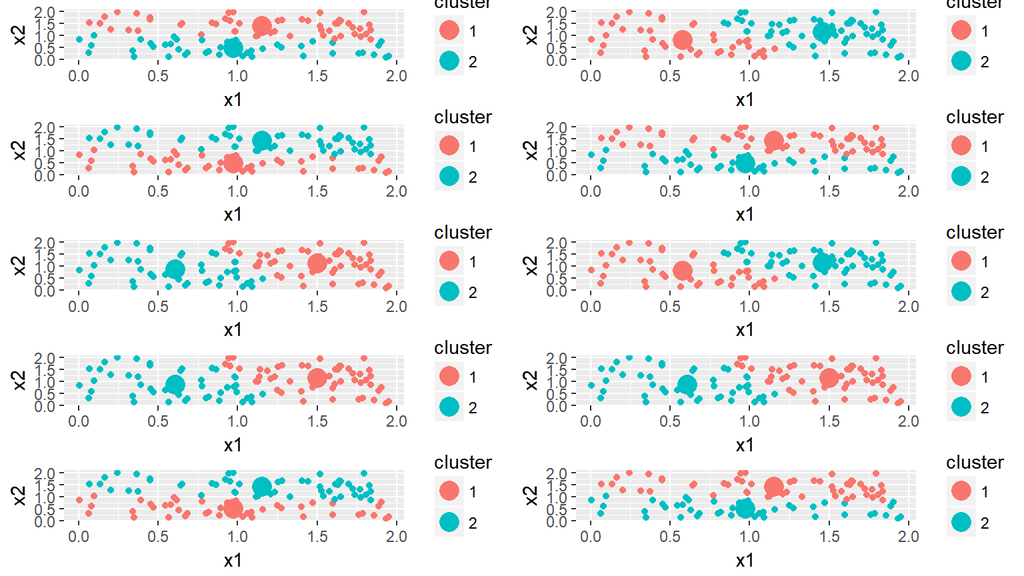

```r
observations_1 <- read_csv("data/observations_1.csv")
observations_2 <- read_csv("data/observations_2.csv")
observations <- observations_1
cluster_center_list <- list()
mutated_observation_list <- list()
set.seed(1002)
for (i in 1:10){
  k <- 2
  k_means_results <- kmeans(observations, centers = k)
  clusters <- k_means_results$cluster
  cluster_centers <- k_means_results$centers

  # Add cluster results to observations. Note we convert to factor since cluster
  # ID's should be treated as categorical
  dataframe <- data.frame(x1 = observations[,1], x2 = observations[,2], cluster = as.factor(clusters))
  mutated_observation_list[[i]] <- dataframe

  # Add cluster ID's to cluster_centers
  cluster_centers <- cluster_centers %>%
    as_tibble() %>%
    mutate(cluster=as.factor(1:k))
  cluster_center_list[[i]] <- cluster_centers
}

plots <- list()

for (i in 1:10){
  plot <- ggplot(NULL, aes(x=x1, y=x2, col=cluster)) +
  geom_point(data=mutated_observation_list[[i]]) +
  geom_point(data=cluster_center_list[[i]], size=5)

  plots[[i]] <- plot
}

cowplot::plot_grid(plotlist = plots, nrow = 5, ncol = 2)
```

**Questions**:

1. Run KMC 10 times on `observations_1` and comment on the consistency of the results. alternating
2. Speculate on the root cause of any consistency or inconsistency in the results.

**Answers**:

#### Observation 1

1. The resulting plots for KMC run 10 times show a somewhat alternating pattern between clusters . They show that the assignment of the same points to either cluster 1 or 2 is alternating. The separation/ clustering is inconsistent. There is also a somewhat alternating pattern on the location of the cluster center hence influencing an alternating pattern on the where the separation between clusters lie.
2. The inconsistency noted above about the assigment of points to either cluster is due to the random assignment of clusters 1 or 2 to the points. The separation/clustering is inconsistent because the algorithm aims to minimize dissimilarity within the group and increase it between the group. Since there is no clear grouping of points in this observation it is harder to attain this goal because there could be more than one way to cluster the points and still attain this goal.

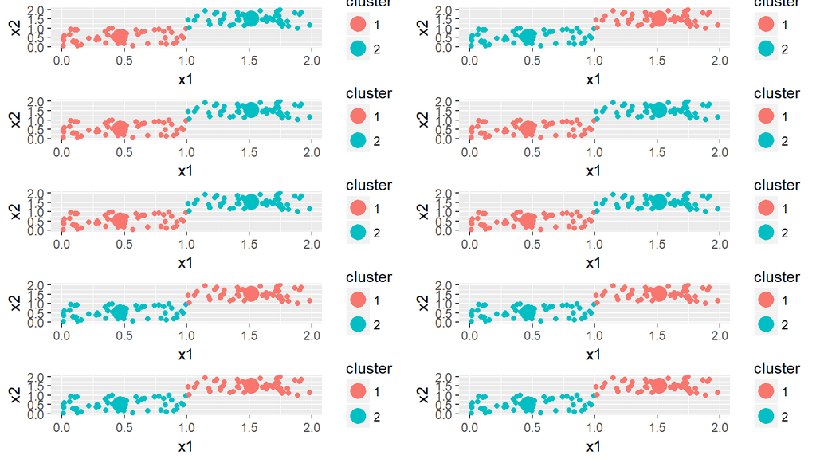

```r
 #Set observations to be one of two datasets
observations <- observations_2

cluster_center_list <- list()
mutated_observation_list <- list()
set.seed(1002)
for (i in 1:10){
  k <- 2
  k_means_results <- kmeans(observations, centers = k)
  clusters <- k_means_results$cluster
  cluster_centers <- k_means_results$centers

  # Add cluster results to observations. Note we convert to factor since cluster
  # ID's should be treated as categorical
  dataframe <- data.frame(x1 = observations[,1], x2 = observations[,2], cluster = as.factor(clusters))
  mutated_observation_list[[i]] <- dataframe

  # Add cluster ID's to cluster_centers
  cluster_centers <- cluster_centers %>%
    as_tibble() %>%
    mutate(cluster=as.factor(1:k))
  cluster_center_list[[i]] <- cluster_centers
}

plots <- list()

for (i in 1:10){
  plot <- ggplot(NULL, aes(x=x1, y=x2, col=cluster)) +
  geom_point(data=mutated_observation_list[[i]]) +
  geom_point(data=cluster_center_list[[i]], size=5)

  plots[[i]] <- plot
}

cowplot::plot_grid(plotlist = plots, nrow = 5, ncol = 2)
```

**Questions**:

3. Run KMC 10 times on `observations_2` and comment on the consistentcy of the results.
4. Speculate on the root cause of any consistency or inconsistency in the results.

**Answers**:

#### Observation 2

3. The resulting plots for KMC run 10 times show a somewhat alternating pattern between the assigment of the two clusters. They show that thereafter the assignment of points to either cluster 1 or 2 is alternating.  
   The separation/ clustering is consistent throughout the 10 times. This means that each cluster either 1 or 2 is always containing the same points regardless of which cluster it is. Also consistent is the location of the cluster centers regardeless of which cluster it is.
4. The inconsistency noted above is due to the random assignment of clusters 1 or 2 to the points. The separation/clustering is consistent because the algorithm aims to minimize dissimilarity within the group and increase it between the group. This observation makes this aim easily attainable because the points themselves are patterned in somewhat clear groups hence its easier to enforce clustering on already grouped data.

# Bonus question: Code your own

Read ISLR page 388 Algorithm 10.1 and implement k-means clustering from scratch. Don’t worry about doing it for general $k$; keep it simple and do it for $k=2$ specifically. Apply it to `observations_2` from above.

```r
# Hint:
library(proxy)
A <- data_frame(
  x1 = c(0, 0.5, 0.75, 1),
  x2 = c(0, 0.5, 0.75, 1)
)
B <- data_frame(
  x1 = c(1, 0),
  x2 = c(1, 0)
)
distance_matrix <- proxy::dist(x=A, y=B)
distance_matrix
apply(distance_matrix, 1, which.min)
```